# Eksamens opgave 2 - OLS og misspecifikation

Lars Boerty Nielsen - 20134303

25 sep 2017

Betragt f?lgende to modeller for bankansattes l?n:

$$salary=\beta_0 +\beta_1 educ +\beta_2 salbegin +\beta_3 male +\beta_4 minority + u$$
$$log(salary)=\beta_0+\beta_1 educ +\beta_2 log(salbegin)+\beta_3 male +\beta_4 minority +u$$

- $salary$ er ?rsl?n (i 1000 US dollars)
- $educ$ er uddannelse m?lt i antal ?r
- $salbegin$ er startl?nnen (i 1000 US dollars) for personens f?rste stilling i samme bank
- $male$ er en dummy-variabel for k?n
- $minority$ er en dummy-variabel der angiver om man tilh?rer en minoritet

Datas?ttet data1, som er tilg?ngelig p?Moodle, indeholder disse variable m?lt for 474 bankansatte.

## 1. Estimer de to modeller vha. OLS. Kommenter p? outputtet, sammenlign og fortolk resultaterne.

```r
reg1 <- lm(salary ~ educ + salbegin + male + minority, data = wage)
reg2 <- lm(lsalary ~ educ + lsalbegin + male + minority, data = wage)
screenreg(list(MODEL1 = reg1, MODEL2 = reg2), digits = 4)
```

```
##
## =======================================
##              MODEL1        MODEL2
## ---------------------------------------
## (Intercept)   -6.8004 ***    0.8487 ***
##               (1.7928)      (0.0751)
## educ           0.9704 ***    0.0233 ***
##               (0.1606)      (0.0039)
## salbegin       1.6156 ***
##               (0.0624)
## male           1.8734 *      0.0482 *
##               (0.8195)      (0.0199)
## minority      -1.7449 *     -0.0424 *
##               (0.8851)      (0.0203)
## lsalbegin                    0.8218 ***
##                             (0.0360)
## ---------------------------------------
## R^2            0.7958        0.8041
## Adj. R^2       0.7941        0.8024
## Num. obs.    474           474
## RMSE           7.7491        0.1766
## =======================================
## *** p < 0.001, ** p < 0.01, * p < 0.05
```

**Model 1:** Vi kan se at alle estimaterne er signifikante, og har de fortegn vi ville forvente. I denne model 1 skal alle estimater tolkes level-level, og det er ligefrem. Vi kan forklare 79% af variationen i dataen med vores uafh?ngige variabler.

**Model 2:** again the same points remain valid as before. But this time we interpert the model both log-level and log-log

education, male and minority is log-level and their beta values can be understood as 1 unit change in education yields 2.3% increase in pay and likewise for male and minority (4% and -4%)

starting salary is also log, this means that 1% change in startingsalary is equal to 0.8% change in curren salary

**Begge modeller** For begge modeller skal det dog understreges at gradena af racisme undervurderes hvis man medtager startl?n, det er klart at hvis denne holdes fast f?r man ikke den racisme med der kunne g?re at l?nnen er laver til at starte med.

## 2. Udf?r grafisk modelkontrol af de to modeller. Hvilken model vil du foretr?kke?

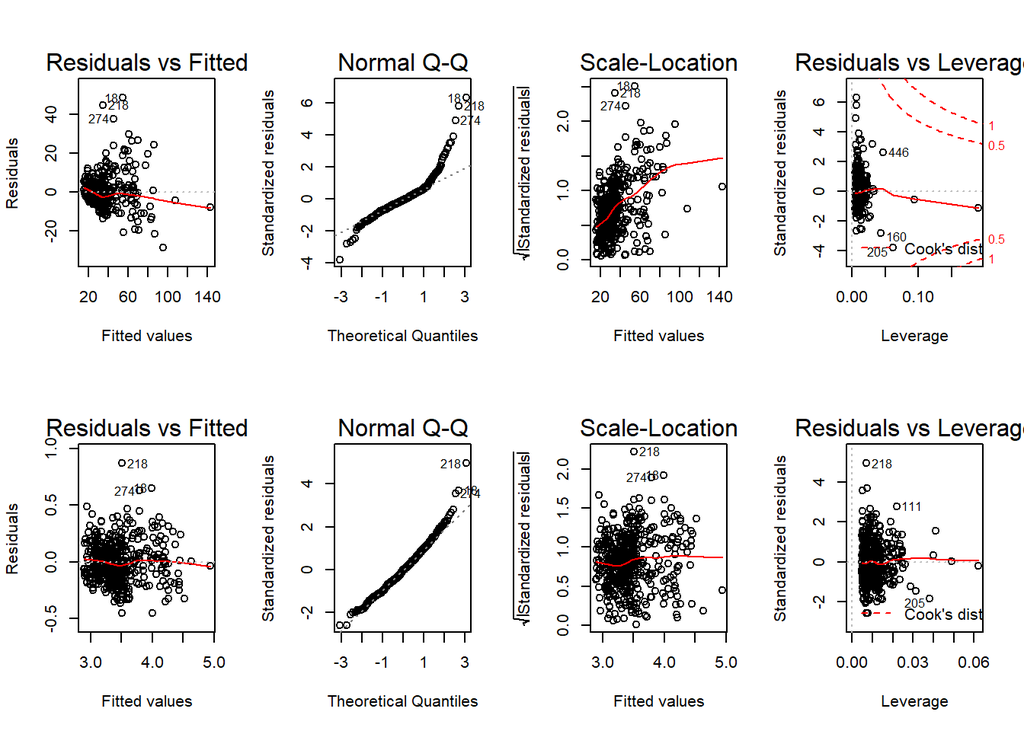

```r
#R har indbygget modelkontrol
par(mfrow = c(2, 4))
plot(reg1)
plot(reg2)
```

### Konklusion

Den 2. model er bedre da indkomst ikke er lin?rt fordelt. Dette kan vi rette ved at tage ln(indkomst) dette g?r at variansen i modellen er mindre.

## 3. Unders?g om de to modeller er misspecificerede vha. RESET-testet.

```r
#f?rst udregner R RESET-testen som handler om at finde om modellen er funktionelt misspecificeret som betyder at modellen ikke korrekt viser forholdet mellem den afh?ngige og den uafh?ngige variabel
resettest(reg1)
```

```
##
##  RESET test
##
## data:  reg1
## RESET = 2.8203, df1 = 2, df2 = 467, p-value = 0.0606
```

```r
resettest(reg2)
```

```
##
##  RESET test
##
## data:  reg2
## RESET = 3.1468, df1 = 2, df2 = 467, p-value = 0.0439
```

```r
#Manuel udregning af RESET-testen
#f?rst definerer jeg de variabler der skal bruges i den nye regression hvor vi inds?tter fittet values ^2 og ^3
reg1reset1 <- reg1$fitted.values^2
reg1reset2 <- reg1$fitted.values^3

reg2reset1 <- reg2$fitted.values^2
reg2reset2 <- reg2$fitted.values^3

#Jeg k?rer mine nye regressioner
reg3 <- lm(salary  ~ educ + salbegin  + male + minority + reg1reset1 + reg1reset2, data = wage)
reg4 <- lm(lsalary ~ educ + lsalbegin + male + minority + reg2reset1 + reg2reset2, data = wage)

#nu skal jeg teste for estimaterne for de nye estimater alle er = 0, det kan jeg ikke g?re vha. standart F-test da denne medtager de andre estimater. Jeg laver en F-test for en joint hypothesis

linearHypothesis(reg3, c("reg1reset1 = 0", "reg1reset2 = 0"))
```

```
## Linear hypothesis test
##
## Hypothesis:
## reg1reset1 = 0
## reg1reset2 = 0
##
## Model 1: restricted model
## Model 2: salary ~ educ + salbegin + male + minority + reg1reset1 + reg1reset2
##
##   Res.Df   RSS Df Sum of Sq      F Pr(>F)
## 1    469 28163
## 2    467 27827  2     336.1 2.8203 0.0606 .
## ---
## Signif. codes:  0 '***' 0.001 '**' 0.01 '*' 0.05 '.' 0.1 ' ' 1
```

```r
linearHypothesis(reg4, c("reg2reset1 = 0", "reg2reset2 = 0"))
```

```
## Linear hypothesis test
##
## Hypothesis:
## reg2reset1 = 0
## reg2reset2 = 0
##
## Model 1: restricted model
## Model 2: lsalary ~ educ + lsalbegin + male + minority + reg2reset1 + reg2reset2
##
##   Res.Df    RSS Df Sum of Sq      F Pr(>F)
## 1    469 14.627
## 2    467 14.433  2   0.19451 3.1468 0.0439 *
## ---
## Signif. codes:  0 '***' 0.001 '**' 0.01 '*' 0.05 '.' 0.1 ' ' 1
```

```r
#Vi kan se at den manuelle RESET-test f?r samme P-v?rdi som den automatiske
```

Vi kan se p? resultaterne giver henholdsvis P=0.0606 (model1) og P=0.0439 (model2) Vores H0 er at der ikke er en funktionel misspicifikation og derfor kan vi konkuderer

model 1 = vi kan med 5% signifikansniveau ikke afvise h0, og vi konkluderer at moodellen ikke er fnktionelt mispeficeret (god) model 2 = Vi kan med 5% signifikansniveau afvise h0 og vi konkluderer at modellen er funktionelt misspeciferet (d?rlig)

## 4. Forklar hvorfor det kunne v?re relevant at medtage $educ^2$ som forklarende variabel i de to modeller. Estimer de to modeller igen hvor $educ^2$ inkluderes (med tilh?rende koefficient $\beta_5$), kommenter kort p? outputtet og udf?r RESET-testet igen.

```r
wage$educ2 <- wage$educ^2

reg5 <- lm(salary  ~ educ + salbegin  + male + minority + educ2, data = wage)
reg6 <- lm(lsalary ~ educ + lsalbegin + male + minority + educ2, data = wage)

screenreg(list(MODEL.1 = reg1, MODEL.1.EDUC2 = reg5, MODEL.2 = reg2, MODEL.2.EDUC2 = reg6), digits=4)
```

```
##
## =====================================================================
##              MODEL.1       MODEL.1.EDUC2  MODEL.2       MODEL.2.EDUC2
## ---------------------------------------------------------------------
## (Intercept)   -6.8004 ***   14.7651 *       0.8487 ***    1.1886 ***
##               (1.7928)      (6.5781)       (0.0751)      (0.2014)
## educ           0.9704 ***   -2.3340 *       0.0233 ***   -0.0168
##               (0.1606)      (0.9836)       (0.0039)      (0.0224)
## salbegin       1.6156 ***    1.4861 ***
##               (0.0624)      (0.0725)
## male           1.8734 *      1.8291 *       0.0482 *      0.0509 *
##               (0.8195)      (0.8105)       (0.0199)      (0.0199)
## minority      -1.7449 *     -1.6535        -0.0424 *     -0.0423 *
##               (0.8851)      (0.8757)       (0.0203)      (0.0203)
## educ2                        0.1325 ***                   0.0016
##                             (0.0389)                     (0.0009)
## lsalbegin                                   0.8218 ***    0.7821 ***
##                                            (0.0360)      (0.0421)
## ---------------------------------------------------------------------
## R^2            0.7958        0.8007         0.8041        0.8055
## Adj. R^2       0.7941        0.7986         0.8024        0.8034
## Num. obs.    474           474            474           474
## RMSE           7.7491        7.6631         0.1766        0.1762
## =====================================================================
## *** p < 0.001, ** p < 0.01, * p < 0.05
```

```r
resettest(reg5)
```

```
##
##  RESET test
##
## data:  reg5
## RESET = 2.0442, df1 = 2, df2 = 466, p-value = 0.1306
```

```r
resettest(reg6)
```

```
##
##  RESET test
##
## data:  reg6
## RESET = 2.2557, df1 = 2, df2 = 466, p-value = 0.1059
```

n?r educ2 er medtaget er ingen af modellerne misspecificerede, men educ2 er kun signifikant i model 1 og ikke i modellen hvor vi har taget log(l?n).

## 5. Test hypotesen $H0 : \beta_1 = \beta_5 = 0$ i begge modeller (fra sp?rgsm?l 4).

Vi vil unders?ge om den ekstra educ2 sammen med educ er signifikant. Dette kan g?res ved en F-test hvor vi laver en restricted model, og derfra bruger SSR-v?rdierne (q = antal parametre fjernet i den restricted)

```r
H0 <- c("educ = 0", "educ2 = 0")
linearHypothesis(reg5, H0)
```

```
## Linear hypothesis test
##
## Hypothesis:
## educ = 0
## educ2 = 0
##
## Model 1: restricted model
## Model 2: salary ~ educ + salbegin + male + minority + educ2
##
##   Res.Df   RSS Df Sum of Sq      F  Pr(>F)
## 1    470 30355
## 2    468 27482  2    2872.3 24.457 7.9e-11 ***
## ---
## Signif. codes:  0 '***' 0.001 '**' 0.01 '*' 0.05 '.' 0.1 ' ' 1
```

```r
linearHypothesis(reg6, H0)
```

```
## Linear hypothesis test
##
## Hypothesis:
## educ = 0
## educ2 = 0
##
## Model 1: restricted model
## Model 2: lsalary ~ educ + lsalbegin + male + minority + educ2
##
##   Res.Df    RSS Df Sum of Sq      F    Pr(>F)
## 1    470 15.755
## 2    468 14.525  2    1.2304 19.822 5.455e-09 ***
## ---
## Signif. codes:  0 '***' 0.001 '**' 0.01 '*' 0.05 '.' 0.1 ' ' 1
```

I begge modeller er p-v?rdierne lave, og det g?r at vi kan forkaste $H_0$(som siger de er nul) og derfor er de ikke 0, s? de har alts? sammenlagt en betydning

## 6. Kunne der v?re problemer med m?lefejl i de to modeller? I hvilke tilf?lde vil det udg?re et problem?

M?lefejl kan forekomme b?de i de uafh?ngige variable og den afh?ngige variabel. De kan opst?, hvis der anvendes upr?cise m?l for variablene.

**m?lefejl i den afh?ngige variabel (l?n)**

$$y^*_i=\beta_0+\beta_1x_1+\beta_2x_2+\dots +\beta_kx_k+u$$
m?lefejlen er givet ved: $e_0=y-y^* \rightarrow y^*=y-e_0$.

dermed kan den originale model omskrives:

$$y=\beta_0+\beta_1x_1+\beta_2x_2+\dots +\beta_kx_k+(u+e_0)$$
Det ses at fejlledet ved m?lefejl i den afh?ngige variabel nu er st?rre, men det giver umiddelbart ikke problemer s? l?nge, fejlledet er uafh?ngigt af de uafh?ngige variable, n?r dette ikke er tilf?ldet, kan der opst? biasedness i modellen.

I variablen salary kan forventes m?lefejl, s?fremt folk har svaret s?dan cirka hvad de tjener i stedet for eksakte tal. En m?de at l?se problemet p? kunne v?re at ?ge antallet af observationer.

**M?lefejl i de ufafh?ngige vaiabler (uddannelse, startl?n, k?n, race)** hvis der f.eks. er udeladte evner, n?r der ses p? uddannelses effekt p? salary.

$$y=\beta_0+\beta_1x^*_1+u$$
Antag at m?lefejlen i $x_1^*$ er givet ved: $e_1=x_1-x_1^* \rightarrow x_1^*=x_1-e_1$. Denne kan v?re positiv eller negativ. Inds?ttes dette i den originale model f?s:
$$y=\beta_0+\beta_1(x^*_1-e_1)+u \rightarrow y=\beta_0+\beta_1x_1-\beta_1e_1+u$$
hvor $E(u)=E(e)=0$.

$e_1$ skal ikke v?re korreleret med $x_1$, der er den observerede v?rdi. Er det tilf?ldet er der ikke et problem. Dog er det et problem, hvis $e_1$ er ukorreleret med den faktiske $x$, og s?ledes korreleret med den observeret $x$. Dette vil give biasedness og inkonsistens, og vil p?virke hele model estimationen, selvom det kun er en variable der er m?lefejl i. Derudover kan variansen p?virkes st?rre end uden m?lefejl.

Det kunne v?re at de adspurgte i stikpr?ven, siger de har mere uddannelse end de faktisk har. Det kan ogs? v?re de har mange ?rs uddannelse, men at det er i forskellige brancher, erhversuddannelse kontra gymnasium og universitet.

Det kan ogs? afh?nge af hvor data stammer fra, hvis en praktikant bliver sat til at udfylde sp?rgeskemaet og ikke kender de eksakte tal, og chefen har m?ske incitament til at overestimere tallene.

## 7. Beregn den pr?dikterede l?n, salary, for hver af de to modeller (fra sp?rgsm?l 4) for de 474 observationer. P? baggrund af disse, hvilken model vil du s? foretr?kke?

$$\bar{R}^2=1-\frac{SSR/(n-k-1)}{SST(n-1)}$$
Den justerede R2 kan ses i summary i de originale modeller

```r
14.7651078+(-2.3340086*wage$educ)+(1.4861052*wage$salbegin)+(1.8290734*wage$male)+(-1.6535355*wage$minority)+(0.1325267*(wage$educ^2))
```

```
##   [1]  51.52740  41.04135  23.67411  24.19134  42.61077  31.46498  39.26703
##   [8]  20.33038  28.52133  25.90327  35.86854  22.58355  30.92602  32.88652
##  [15]  27.73234  29.96150  32.57956  54.05963  28.84692  23.00536  33.63938
##  [22]  24.96423  24.41572  17.56226  21.29490  30.12749  60.92833  32.57956
##  [29] 138.94885  32.57956  28.84692  86.96489  33.69414  79.51950  59.79941
##  [36]  21.29343  26.07881  32.04060  33.81492  21.29490  21.35183  35.92330
##  [43]  28.84692  27.58082  27.73234  28.52133  30.36159  28.62401  35.92330
##  [50]  48.44216  29.96150  33.69414  56.53094  27.73234  29.96150  31.46498
##  [57]  34.80872  29.63591  30.92602  28.30797  19.23981  45.49967  54.22651
##  [64]  44.38509  28.02665  64.67331  44.74175  45.09842  50.32951  41.49619
##  [71]  67.20021  38.09770  21.44495  38.55254  26.73800  26.73800  22.78245
##  [78]  21.44495  32.97064  38.09770  22.11370  25.36431  20.90600  19.19406
##  [85]  36.81496  34.80872  28.62401  62.80082  60.92833  19.06427  22.55953
##  [92]  20.84760  22.11370  20.77621  21.44495  27.04186  42.54177  27.04186
##  [99]  20.46017  58.35885  46.61425  33.29945  72.11870  34.80872  31.46498
```

[output cut: 53 more lines]

```r
1.188632947+(-0.016785373*wage$educ)+(0.782093764*wage$lsalbegin)+(0.050895778*wage$male)+(-0.042308975*wage$minority)+(0.001621298*(wage$educ^2))
```

```
##   [1] 3.930194 3.678483 3.164105 3.176085 3.733642 3.388088 3.645009
##   [8] 3.001712 3.292489 3.256223 3.527610 3.110130 3.388064 3.465918
##  [15] 3.307119 3.389520 3.430373 3.978304 3.349404 3.134213 3.453068
##  [22] 3.220106 3.141792 2.896802 2.977771 3.334129 4.097330 3.430373
##  [29] 4.932855 3.430373 3.349404 4.483062 3.470489 4.390749 4.082788
##  [36] 3.051068 3.264810 3.428180 3.461655 2.977771 3.091904 3.545031
##  [43] 3.349404 3.286842 3.307119 3.292489 3.413166 3.341128 3.545031
##  [50] 3.862703 3.389520 3.470489 4.018314 3.307119 3.389520 3.388088
##  [57] 3.508648 3.337192 3.388064 3.347211 2.947736 3.794562 3.978354
##  [64] 3.767117 3.303136 4.165950 3.776005 3.784792 3.903478 3.705199
##  [71] 4.202901 3.595661 3.059671 3.624787 3.215182 3.215182 3.123989
##  [78] 3.059671 3.429246 3.595661 3.092491 3.256199 3.071321 2.987620
##  [85] 3.572966 3.508648 3.341128 4.132393 4.097330 2.939150 3.113630
##  [92] 3.029929 3.092491 3.025414 3.059671 3.284649 3.703566 3.284649
##  [99] 3.050182 4.054128 3.821076 3.478416 4.286734 3.508648 3.388088
```

[output cut: 53 more lines]